# Project CS-711

## Simplified Approximation of Extraordinary Losses on a Lending Portfolio

Project Description Financial Institutions are expected to hold capital reserves sufficient to withstand unlikely but potentially catastrophic loss events. The reserve for a risky loan is higher than the reserve for a safer loan, and this difference should be reflected in the interest rate offered by the lender. However, the loss calculations are too cumbersome to be performed every time someone seeks a loan. The goal of this project is to approximate those loss calculations, with an alternative model that could be fast enough to use during lending, but sufficiently accurate to avoid under- or over- pricing loans.

```python
import pandas as pd
import numpy as np
import matplotlib.pyplot as plt
import seaborn as sns
```

```python
df = pd.read_csv("Development Dataset - With Actuals.csv")
```

```python
df.head()
```

|  | Instrument | Instrument Type | Instrument Subtype | Counterparty Alias | MTM Exposure | Book Exposure | 1-Year Likelihood | Severity Used | Industry Alias | Commitment | Country of Incorporation | Maturity Date | Time to Maturity | Capital - EL Tail Risk Contribution (Capped) | Capitalization Rate - EL Tail Risk Contribution | Asset Recovery Correlation | Recovery R-Squared for Simulation | Asset R-Squared for Simulation |
| --- | --- | --- | --- | --- | --- | --- | --- | --- | --- | --- | --- | --- | --- | --- | --- | --- | --- | --- |
| 0 | 86540 | Loan | Term Loan Amortizing | C23099 | 224013.330 | 224013.33 | 0.160200 | 0.057 | IND1 | 224013.33 | CAN | 12/15/2037 | 16.375086 | 57797.73 | 0.258010 | 0.26706 | 0.34109 | 0.0976 |
| 1 | 86099 | Loan | Revolver | C43055 | 135000.000 | 135000.00 | 0.036900 | 0.817 | IND1 | 135000.00 | CAN | 04/18/2022 | 0.714579 | 23359.48 | 0.173033 | 0.26706 | 0.34109 | 0.1077 |
| 2 | 5738 | Loan | Term Loan Amortizing | C11421 | 36190.953 | 36190.95 | 0.036900 | 0.019 | IND2 | 36190.95 | CAN | 11/17/2031 | 10.297057 | 1558.02 | 0.043050 | 0.33000 | 0.34000 | 0.0469 |
| 3 | 165996 | Loan | Term Loan Amortizing | C44251 | 84600.000 | 84600.00 | 0.006525 | 0.019 | IND1 | 84600.00 | CAN | 04/03/2028 | 6.674880 | 703.86 | 0.008320 | 0.26706 | 0.34109 | 0.1077 |
| 4 | 118169 | Loan | Term Loan Amortizing | C53713 | 37508.787 | 37508.78 | 0.020475 | 0.247 | IND1 | 37508.78 | CAN | 01/03/2040 | 18.425736 | 3602.36 | 0.096041 | 0.33000 | 0.34000 | 0.0495 |

```python
df.shape
```

```
(151532, 18)
```

```python
df.info()
```

```
<class 'pandas.core.frame.DataFrame'>
RangeIndex: 151532 entries, 0 to 151531
Data columns (total 18 columns):
 #   Column                                           Non-Null Count   Dtype
---  ------                                           --------------   -----
 0   Instrument                                       151532 non-null  int64
 1   Instrument Type                                  151532 non-null  object
 2   Instrument Subtype                               151500 non-null  object
 3   Counterparty Alias                               151532 non-null  object
 4   MTM Exposure                                     151532 non-null  float64
 5   Book Exposure                                    151532 non-null  float64
 6   1-Year Likelihood                                151532 non-null  float64
 7   Severity Used                                    151532 non-null  float64
 8   Industry Alias                                   151532 non-null  object
 9   Commitment                                       151532 non-null  float64
 10  Country of Incorporation                         151532 non-null  object
 11  Maturity Date                                    151532 non-null  object
 12  Time to Maturity                                 151532 non-null  float64
 13  Capital - EL Tail Risk Contribution (Capped)     151532 non-null  float64
 14  Capitalization Rate - EL Tail Risk Contribution  151532 non-null  float64
 15  Asset Recovery Correlation                       151532 non-null  float64
 16  Recovery R-Squared for Simulation                151532 non-null  float64
 17  Asset R-Squared for Simulation                   151532 non-null  float64
dtypes: float64(11), int64(1), object(6)
memory usage: 20.8+ MB
```

# EDA

## Missing Values

```python
df.isnull().sum()
```

```
Instrument                                          0
Instrument Type                                     0
Instrument Subtype                                 32
Counterparty Alias                                  0
MTM Exposure                                        0
Book Exposure                                       0
1-Year Likelihood                                   0
Severity Used                                       0
Industry Alias                                      0
Commitment                                          0
Country of Incorporation                            0
Maturity Date                                       0
Time to Maturity                                    0
Capital - EL Tail Risk Contribution (Capped)        0
Capitalization Rate - EL Tail Risk Contribution     0
Asset Recovery Correlation                          0
Recovery R-Squared for Simulation                   0
Asset R-Squared for Simulation                      0
dtype: int64
```

```python
missing_val_features = [f for f in df.columns if df[f].isnull().sum() > 0]
```

```python
missing_val_features
```

```
['Instrument Subtype']
```

```python
for feature in missing_val_features:
    print("The missing values in {} is {}%".format(feature,np.round(df[feature].isnull().mean(),5)))
```

```
The missing values in Instrument Subtype is 0.00021%
```

```python
df.dropna(inplace=True)
```

```python
df.isnull().sum()
```

```
Instrument                                         0
Instrument Type                                    0
Instrument Subtype                                 0
Counterparty Alias                                 0
MTM Exposure                                       0
Book Exposure                                      0
1-Year Likelihood                                  0
Severity Used                                      0
Industry Alias                                     0
Commitment                                         0
Country of Incorporation                           0
Maturity Date                                      0
Time to Maturity                                   0
Capital - EL Tail Risk Contribution (Capped)       0
Capitalization Rate - EL Tail Risk Contribution    0
Asset Recovery Correlation                         0
Recovery R-Squared for Simulation                  0
Asset R-Squared for Simulation                     0
dtype: int64
```

```python
df.shape
```

```
(151500, 18)
```

## Outliers

```python
num_feat = [f for f in df.columns if df[f].dtype != "O"]
```

```python
cont_feat = [f for f in num_feat if df[f].unique().sum() > 25]
```

```python
finite_features = [f for f in num_feat if len(df[f].unique()) <= 30]
```

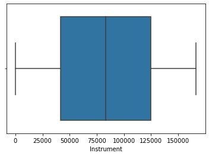

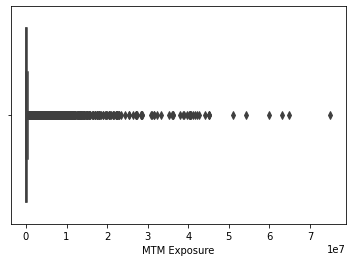

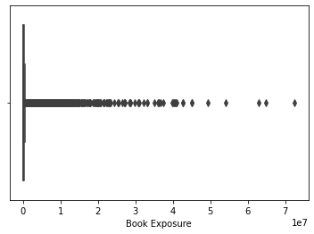

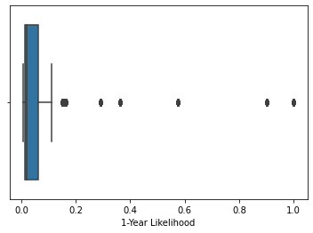

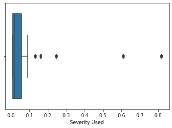

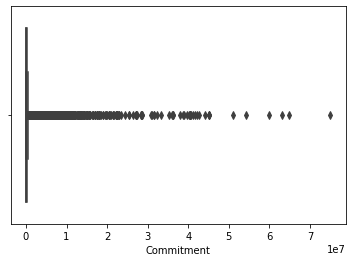

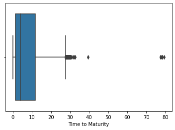

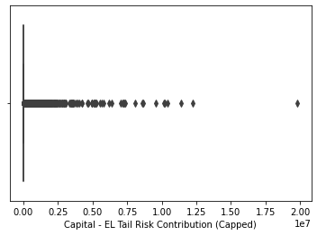

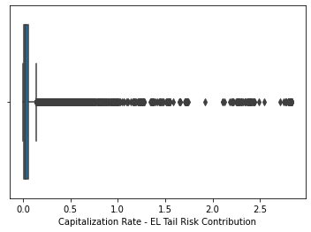

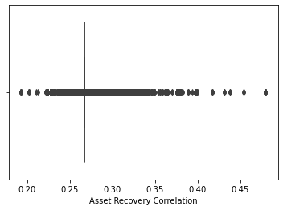

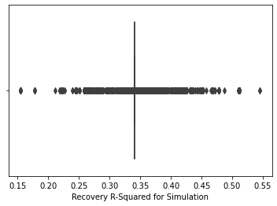

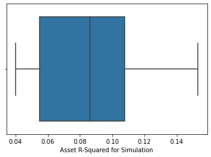

```python
for f in num_feat:
    plt.figure()
    sns.boxplot(data=df,x=f)
    plt.show()
```

We can see there are a lot of outliers and there's no normal distribtion.

```python
outlier_feats = ['MTM Exposure','1-Year Likelihood','Severity Used','Commitment','Capital - EL Tail Risk Contribution (Capped)',
       'Capitalization Rate - EL Tail Risk Contribution','Asset Recovery Correlation', 'Time to Maturity',
       'Asset R-Squared for Simulation','Recovery R-Squared for Simulation']
```

We will remove outliers from above features

We will use Z-Score technique to handle outliers.

```python
from scipy import stats
import numpy as np
z_scores = np.abs(stats.zscore(df[outlier_feats]))
```

```python
np.where(z_scores>3)
```

```
(array([     1,     27,     33, ..., 151459, 151461, 151496], dtype=int64),
 array([2, 1, 2, ..., 2, 1, 2], dtype=int64))
```

```python
print(df.shape)
```

```
(151500, 18)
```

```python
df_clean = df.copy()
```

```python
df_clean = df_clean[(z_scores < 3).all(axis=1)]
```

```python
print(df_clean.shape)
```

```
(139086, 18)
```

## Categorical Features

Now let's handle categorical features in data

```python
df = df_clean.copy()
```

```python
categorical_feat = ["Instrument Type","Instrument Subtype","Industry Alias", "Country of Incorporation"]
```

```python
categorical_feat
```

```
['Instrument Type',
 'Instrument Subtype',
 'Industry Alias',
 'Country of Incorporation']
```

```python
 for f in categorical_feat:
    print("No of Categories in {} are {}".format(f,len(df[f].unique())))
```

```
No of Categories in Instrument Type are 1
No of Categories in Instrument Subtype are 2
No of Categories in Industry Alias are 36
No of Categories in Country of Incorporation are 1
```

```python
# Here, Instrument Type and Country of Incoroporation has just on drop these coloumns.
categorical_feat = ["Instrument Subtype","Industry Alias"]
#categorical_feat = ["Instrument Subtype"]
```

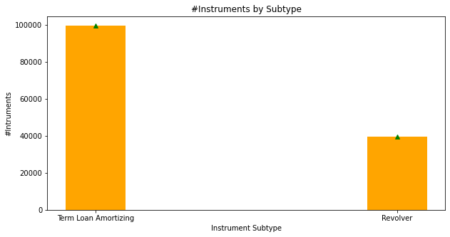

```python
plt.figure(figsize=(10,5))
plt.bar(df['Instrument Subtype'].unique(), df['Instrument Subtype'].value_counts().tolist(), 0.2, color='Orange')
plt.plot(df['Instrument Subtype'].unique(), df['Instrument Subtype'].value_counts().tolist(), 'g^')
plt.xlabel('Instrument Subtype')
plt.ylabel('#Intruments')
plt.title(f"#Instruments by Subtype")
plt.show()
```

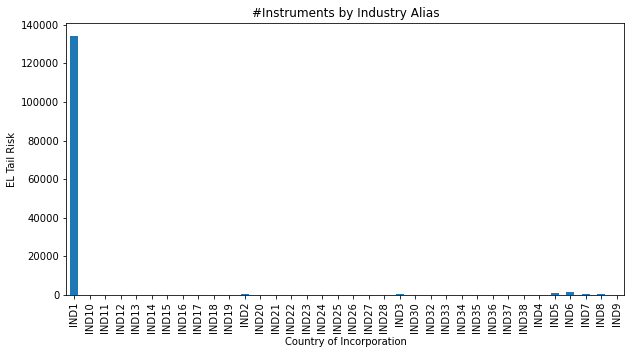

```python
plt.figure(figsize=(10,5))
df.groupby(df['Industry Alias'])["Capital - EL Tail Risk Contribution (Capped)"].count().plot.bar()
plt.xlabel(f)
plt.ylabel('EL Tail Risk')
plt.title('#Instruments by Industry Alias')
plt.show()
```

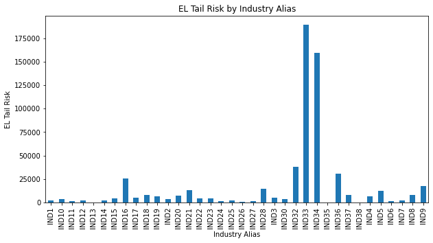

```python
plt.figure(figsize=(10,5))
df.groupby(df['Industry Alias'])["Capital - EL Tail Risk Contribution (Capped)"].median().plot.bar()
plt.xlabel('Industry Alias')
plt.ylabel('EL Tail Risk')
plt.title('EL Tail Risk by Industry Alias')
plt.show()
```

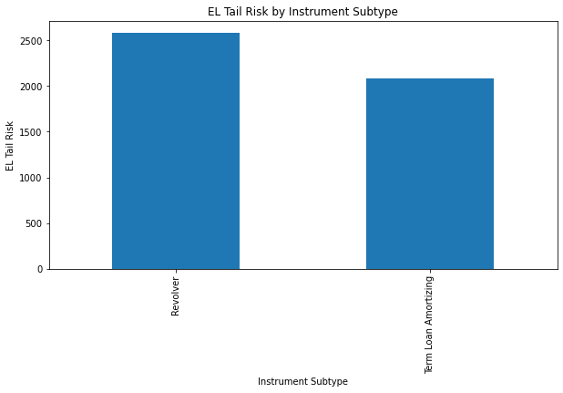

```python
plt.figure(figsize=(10,5))
df.groupby(df['Instrument Subtype'])["Capital - EL Tail Risk Contribution (Capped)"].median().plot.bar()
plt.xlabel('Instrument Subtype')
plt.ylabel('EL Tail Risk')
plt.title('EL Tail Risk by Instrument Subtype')
plt.show()
```

```python
print(f"There are {df['Counterparty Alias'].nunique()} Counterparty Alias")
```

```
There are 53144 Counterparty Alias
```

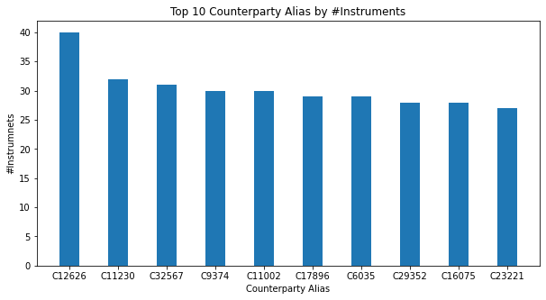

```python
grouped_counterparty = df.groupby(by=['Counterparty Alias']).count()
top10_counterparty = grouped_counterparty.iloc[:,1].sort_values(ascending=False).head(10)
plt.figure(figsize=(10, 5))
plt.bar(top10_counterparty.index, top10_counterparty.values, 0.4)
plt.xlabel('Counterparty Alias')
plt.ylabel('#Instrumnets')
plt.title('Top 10 Counterparty Alias by #Instruments')
plt.show()
```

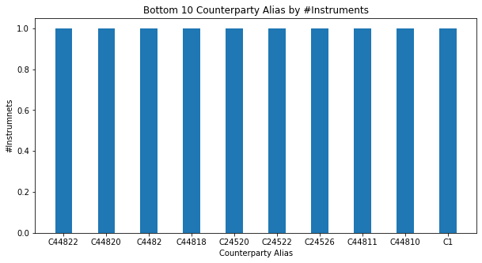

```python
bottom10_counterparty = grouped_counterparty.iloc[:,1].sort_values(ascending=False).tail(10)
plt.figure(figsize=(10, 5))
plt.bar(bottom10_counterparty.index, bottom10_counterparty.values, 0.4)
plt.xlabel('Counterparty Alias')
plt.ylabel('#Instrumnets')
plt.title('Bottom 10 Counterparty Alias by #Instruments')
plt.show()
```

#### Analysis on Industry Alias

```python
print(f"Number of unique Industry groups: {df['Industry Alias'].nunique()}")
```

```
Number of unique Industry groups: 36
```

```
Industry Alias
IND1     96.431704
IND6      1.245273
IND5      0.759242
IND3      0.341515
IND2      0.287592
IND8      0.263147
IND7      0.202752
IND11     0.089153
IND10     0.088434
IND14     0.060394
Name: Instrument, dtype: float64
```

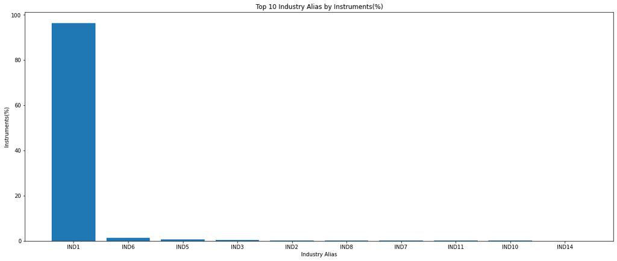

```python
grouped_industry = df.groupby(['Industry Alias'])
grouped_ind_ins_top = (grouped_industry['Instrument'].count()/df.shape[0]*100).sort_values(ascending = False).head(10)
print(grouped_ind_ins_top)
plt.figure(figsize=(20,8))
plt.bar(grouped_ind_ins_top.index, grouped_ind_ins_top.values)
plt.title('Top 10 Industry Alias by Instruments(%)')
plt.xlabel('Industry Alias')
plt.ylabel('Instruments(%)')
plt.show()
```

##### Above results shows that majority of the instruments belongs to the IND1, it could infer that FCC has most the assets in terms of instruments that belongs from IND1.

```
Insights for IND1:
Instrument Type
Loan    134123
Name: Instrument, dtype: int64

Instrument Subtype
Revolver                38297
Term Loan Amortizing    95826
Name: Instrument, dtype: int64
```

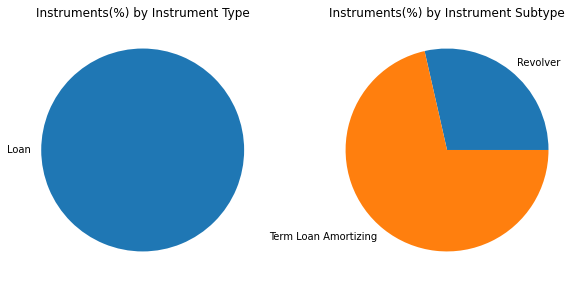

```python
# Categorization at Instrument Type Level
grouped_IND1_ins_type = df[df['Industry Alias']=='IND1'].groupby(by=['Instrument Type'])
IND1_ins_type = grouped_IND1_ins_type['Instrument'].count()

# Categorization at Instrument Subtype Level
grouped_IND1_ins_stype = df[df['Industry Alias']=='IND1'].groupby(by=['Instrument Subtype'])
IND1_ins_stype = grouped_IND1_ins_stype['Instrument'].count()
print(f'Insights for IND1:\n{IND1_ins_type}\n\n{IND1_ins_stype}')

figure = plt.figure(figsize=(10,10))
gs = figure.add_gridspec(1, 2)
axis1 = figure.add_subplot(gs[0, 0])
axis1.pie(IND1_ins_type.values, labels = IND1_ins_type.index)
axis1.set_title('Instruments(%) by Instrument Type')

axis2 = figure.add_subplot(gs[0, 1])
axis2.pie(IND1_ins_stype.values, labels = IND1_ins_stype.index)
axis2.set_title('Instruments(%) by Instrument Subtype')
```

##### Above results describes that all instruments that belongs to IND1 are of Loan type and most of them are of 'Term Loan Amortizing' instrument subtype.

```
Industry Alias
IND27    0.002157
IND35    0.002157
IND36    0.001438
IND37    0.001438
IND13    0.001438
IND22    0.000719
IND17    0.000719
IND38    0.000719
IND33    0.000719
IND34    0.000719
Name: Instrument, dtype: float64
```

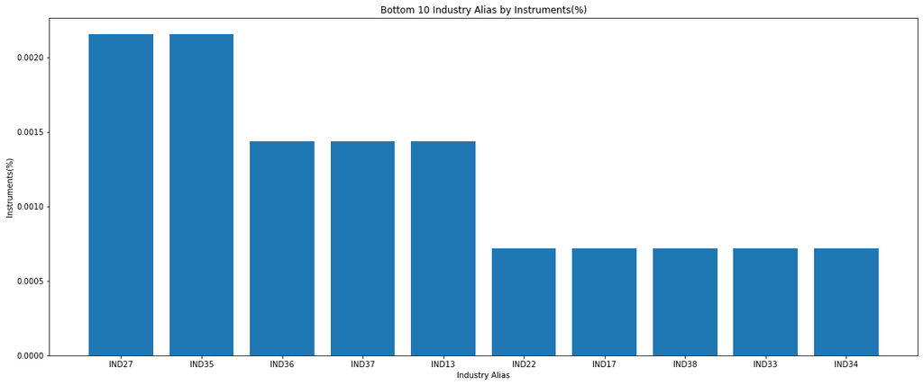

```python
grouped_ind_ins_bottom = (grouped_industry['Instrument'].count()/df.shape[0]*100).sort_values(ascending = False).tail(10)
print(grouped_ind_ins_bottom)
plt.figure(figsize=(20,8))
plt.bar(grouped_ind_ins_bottom.index, grouped_ind_ins_bottom.values)
plt.title('Bottom 10 Industry Alias by Instruments(%)')
plt.xlabel('Industry Alias')
plt.ylabel('Instruments(%)')
plt.show()
```

##### We can se there is relation between categorical variables and target variable.

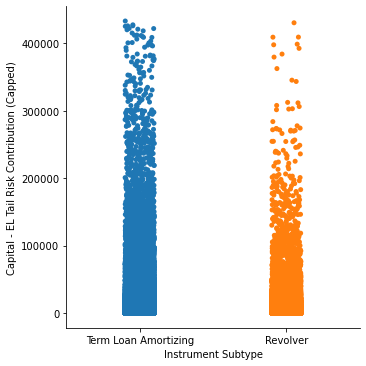

```python
plt.figure(figsize=(15,10))
sns.catplot(x="Instrument Subtype", y="Capital - EL Tail Risk Contribution (Capped)",data=df)
plt.show()
```

##### For "Industry Alias" feature, we have many category, but with few categories have frequent values. rest are very infrequent. So we will drop categories occured less than 250 times. This will reduce the sparsity in the oneHot encoding and hence better for model building

```python
df["Industry Alias"].value_counts()
```

```
IND1     134123
IND6       1732
IND5       1056
IND3        475
IND2        400
IND8        366
IND7        282
IND11       124
IND10       123
IND14        84
IND4         67
IND23        52
IND21        37
IND9         27
IND12        25
IND25        20
IND28        13
IND18        12
IND32        12
IND15         9
IND30         7
IND24         5
IND26         5
IND19         5
IND20         4
IND16         4
IND35         3
IND27         3
IND13         2
IND36         2
IND37         2
IND34         1
IND17         1
IND33         1
IND22         1
IND38         1
Name: Industry Alias, dtype: int64
```

```python
df = df[df["Industry Alias"].map(df["Industry Alias"].value_counts()) > 250]
# Dropping categories with occured less than 250 time (very less frequent). This will reduce sparsity in OneHotEncoding matrix.
```

```python
df["Industry Alias"].value_counts()
```

```
IND1    134123
IND6      1732
IND5      1056
IND3       475
IND2       400
IND8       366
IND7       282
Name: Industry Alias, dtype: int64
```

```python
categorical_feat
```

```
['Instrument Subtype', 'Industry Alias']
```

Performing One hot encoding

```python
df = pd.get_dummies(df,prefix=['Instrument Subtype','Industry Alias'], columns = ['Instrument Subtype','Industry Alias'], drop_first=True)
```

```python
encoded_cols =[f for f in df.columns if "_" in f]
```

```python
encoded_cols
```

```
['Instrument Subtype_Term Loan Amortizing',
 'Industry Alias_IND2',
 'Industry Alias_IND3',
 'Industry Alias_IND5',
 'Industry Alias_IND6',
 'Industry Alias_IND7',
 'Industry Alias_IND8']
```

```python
df.head()
```

|  | Instrument | Instrument Type | Counterparty Alias | MTM Exposure | Book Exposure | 1-Year Likelihood | Severity Used | Commitment | Country of Incorporation | Maturity Date | ... | Asset Recovery Correlation | Recovery R-Squared for Simulation | Asset R-Squared for Simulation | Instrument Subtype_Term Loan Amortizing | Industry Alias_IND2 | Industry Alias_IND3 | Industry Alias_IND5 | Industry Alias_IND6 | Industry Alias_IND7 | Industry Alias_IND8 |
| --- | --- | --- | --- | --- | --- | --- | --- | --- | --- | --- | --- | --- | --- | --- | --- | --- | --- | --- | --- | --- | --- |
| 0 | 86540 | Loan | C23099 | 224013.330 | 224013.33 | 0.160200 | 0.057 | 224013.33 | CAN | 12/15/2037 | ... | 0.26706 | 0.34109 | 0.0976 | 1 | 0 | 0 | 0 | 0 | 0 | 0 |
| 2 | 5738 | Loan | C11421 | 36190.953 | 36190.95 | 0.036900 | 0.019 | 36190.95 | CAN | 11/17/2031 | ... | 0.33000 | 0.34000 | 0.0469 | 1 | 1 | 0 | 0 | 0 | 0 | 0 |
| 3 | 165996 | Loan | C44251 | 84600.000 | 84600.00 | 0.006525 | 0.019 | 84600.00 | CAN | 04/03/2028 | ... | 0.26706 | 0.34109 | 0.1077 | 1 | 0 | 0 | 0 | 0 | 0 | 0 |
| 4 | 118169 | Loan | C53713 | 37508.787 | 37508.78 | 0.020475 | 0.247 | 37508.78 | CAN | 01/03/2040 | ... | 0.33000 | 0.34000 | 0.0495 | 1 | 0 | 0 | 0 | 0 | 0 | 0 |
| 5 | 25688 | Loan | C2146 | 134033.940 | 134033.94 | 0.006525 | 0.019 | 134033.94 | CAN | 06/03/2030 | ... | 0.26706 | 0.34109 | 0.1077 | 1 | 0 | 0 | 0 | 0 | 0 | 0 |

5 rows × 23 columns